# Data Analysis: Multi-Site Marketing Dashboard

**Файли даних:**

- `orders.csv` — замовлення з різних сайтів
- `traffic_sources.csv` — джерела трафіку (включаючи AI-фічі)
- `site_event_log.csv` — події користувачів на сайтах
- `site_mapping.csv` — додаткова інформація про сайти

**Структура аналізу:**

1. Аналітика трафіку (AI-джерела)
2. Аналіз продажів
3. Івенти на сайтах
4. Бізнес-гіпотези та рекомендації

```python
# Імпорт бібліотек
import pandas as pd
import numpy as np
import matplotlib.pyplot as plt
import matplotlib.ticker as mticker
import seaborn as sns
import warnings
warnings.filterwarnings('ignore')

plt.rcParams['figure.figsize'] = (14, 6)
plt.rcParams['font.size'] = 11
sns.set_style('whitegrid')
PALETTE = 'tab10'

print('Libraries loaded successfully')
```

```
Libraries loaded successfully
```

```python
# Огляд датасету
orders   = pd.read_csv('datasets/orders.csv', parse_dates=['date'])
traffic  = pd.read_csv('datasets/traffic_sources.csv', parse_dates=['date'])
events   = pd.read_csv('datasets/site_event_log.csv', parse_dates=['timestamp'])
mapping  = pd.read_csv('datasets/site_mapping.csv')

print('=== orders.csv ===')
print(orders.shape)
print(orders.dtypes)
print(orders.head(3))
print()
print('=== traffic_sources.csv ===')
print(traffic.shape)
print(traffic.dtypes)
print(traffic.head(3))
print()
print('=== site_event_log.csv ===')
print(events.shape)
print(events.dtypes)
print(events.head(3))
print()
print('=== site_mapping.csv ===')
print(mapping)
```

```
=== orders.csv ===
(300, 7)
order_id                      str
site                          str
region                        str
niche                         str
amount_usd                float64
date               datetime64[us]
is_new_customer              bool
dtype: object
    order_id             site region        niche  amount_usd       date  \
0  ORD126225   typemaster.org     CA  Programming       92.42 2025-06-08
1  ORD809570   typemaster.org     EU      Nursing       76.54 2025-06-19
2  ORD131244  essayhubpro.net     US  Programming       96.19 2025-06-08

   is_new_customer
0             True
1            False
2             True

=== traffic_sources.csv ===
(400, 4)
site                   str
source                 str
sessions             int64
date        datetime64[us]
dtype: object
                 site            source  sessions       date
0  progassignments.io   people_also_ask        66 2025-06-05
1      editgenius.net  featured_snippet        77 2025-06-20
2      editgenius.net          referral       129 2025-06-04

=== site_event_log.csv ===
(500, 4)
site                    str
event                   str
user_id                 str
timestamp    datetime64[us]
dtype: object
                 site       event    user_id  timestamp
0     essayhubpro.net  conversion  user_8381 2025-06-16
1  progassignments.io  conversion  user_7150 2025-06-14
2      slidecraft.com   cta_click  user_2404 2025-06-25

=== site_mapping.csv ===
                  site region         niche  is_new_site
0      essayhubpro.net     UK      Academic         True
1       typemaster.org     AU       Editing         True
2       slidecraft.com     UK  Presentation         True
3   progassignments.io     US       Editing        False
4         paperwise.co     UK       Nursing         True
5      nursingessay.us     EU       Editing        False
6  leadacademica.co.uk     AU  Presentation         True
7    writemaster.co.uk     US       Editing         True
8       editgenius.net     EU       Editing        False
```

## 1. Аналітика трафіку: AI-джерела

AI-джерела: `ai_overview`, `featured_snippet`, `people_also_ask`

```python
# Визначаємо діапазон дат
print('Діапазон дат у traffic_sources.csv:')
print(f"  Min: {traffic['date'].min().date()}")
print(f"  Max: {traffic['date'].max().date()}")
print(f"  Всього днів: {(traffic['date'].max() - traffic['date'].min()).days + 1}")
print()
print('Унікальні джерела трафіку:', sorted(traffic['source'].unique()))
```

```
Діапазон дат у traffic_sources.csv:
  Min: 2025-06-01
  Max: 2025-06-30
  Всього днів: 30

Унікальні джерела трафіку: ['ai_overview', 'direct', 'featured_snippet', 'organic', 'paid', 'people_also_ask', 'referral']
```

```python
AI_SOURCES = ['ai_overview', 'featured_snippet', 'people_also_ask']

# Динамічно визначаємо два 15-денні вікна відносно максимальної дати в даних
max_date = traffic['date'].max()

# Останні 15 днів: [max_date - 14 ... max_date]
period2_start = max_date - pd.Timedelta(days=14)

# Попередні 15 днів: [max_date - 29 ... max_date - 15]
period1_end   = period2_start - pd.Timedelta(days=1)
period1_start = period1_end   - pd.Timedelta(days=14)

period1 = traffic[(traffic['date'] >= period1_start) & (traffic['date'] <= period1_end)]
period2 = traffic[(traffic['date'] >= period2_start) & (traffic['date'] <= max_date)]

print(f"Попередні 15 днів: {period1_start.date()} – {period1_end.date()}   ({len(period1)} рядків)")
print(f"Останні  15 днів:  {period2_start.date()} – {max_date.date()}   ({len(period2)} рядків)")
```

```
Попередні 15 днів: 2025-06-01 – 2025-06-15   (195 рядків)
Останні  15 днів:  2025-06-16 – 2025-06-30   (205 рядків)
```

```python
def ai_sessions_by_site(df):
    return (
        df[df['source'].isin(AI_SOURCES)]
        .groupby('site')['sessions']
        .sum()
        .rename('sessions')
    )

ai_p1 = ai_sessions_by_site(period1).rename('p1_sessions')
ai_p2 = ai_sessions_by_site(period2).rename('p2_sessions')

ai_compare = pd.concat([ai_p1, ai_p2], axis=1).fillna(0).astype(int)
ai_compare['absolute_growth'] = ai_compare['p2_sessions'] - ai_compare['p1_sessions']
ai_compare['relative_growth_pct'] = (
    (ai_compare['p2_sessions'] - ai_compare['p1_sessions'])
    / ai_compare['p1_sessions'].replace(0, np.nan)
    * 100
).round(1)

ai_compare = ai_compare.sort_values('relative_growth_pct', ascending=False)

p1_label = f"Попередні 15д ({period1_start.strftime('%d.%m')}–{period1_end.strftime('%d.%m')})"
p2_label = f"Останні 15д ({period2_start.strftime('%d.%m')}–{max_date.strftime('%d.%m')})"
ai_compare.columns = [p1_label, p2_label, 'Абс. приріст', 'Відн. приріст, %']

print('AI-трафік по сайтах: останні 15 днів vs попередні 15 днів')
print(ai_compare.to_string())
```

```
AI-трафік по сайтах: останні 15 днів vs попередні 15 днів
                     Попередні 15д (01.06–15.06)  Останні 15д (16.06–30.06)  Абс. приріст  Відн. приріст, %
site
leadacademica.co.uk                          716                       1966          1250             174.6
typemaster.org                               494                       1117           623             126.1
writemaster.co.uk                            611                        667            56               9.2
nursingessay.us                             1154                       1087           -67              -5.8
slidecraft.com                              1264                       1104          -160             -12.7
editgenius.net                               571                        477           -94             -16.5
paperwise.co                                1210                        921          -289             -23.9
essayhubpro.net                             1357                        985          -372             -27.4
progassignments.io                          1061                        660          -401             -37.8
```

```python
# Розбивка AI-трафіку по конкретному джерелу
ai_traffic = traffic[traffic['source'].isin(AI_SOURCES)]

ai_by_source = (
    ai_traffic
    .groupby(['site', 'source'])['sessions']
    .sum()
    .unstack(fill_value=0)
)

ai_by_source['total_ai'] = ai_by_source.sum(axis=1)
ai_by_source = ai_by_source.sort_values('total_ai', ascending=False)
ai_by_source.loc['TOTAL'] = ai_by_source.sum()

print('Сесії за AI-джерелами по кожному сайту:')
print(ai_by_source.to_string())
```

```
Сесії за AI-джерелами по кожному сайту:
source               ai_overview  featured_snippet  people_also_ask  total_ai
site
leadacademica.co.uk          819               843             1020      2682
slidecraft.com               498               607             1263      2368
essayhubpro.net              704               757              881      2342
nursingessay.us              889               892              460      2241
paperwise.co                 603              1123              405      2131
progassignments.io           416               613              692      1721
typemaster.org               912               372              327      1611
writemaster.co.uk            427               469              382      1278
editgenius.net                 0               695              353      1048
TOTAL                       5268              6371             5783     17422
```

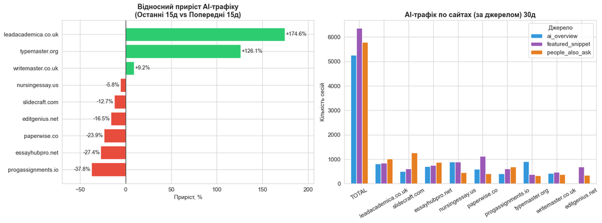

```python
fig, axes = plt.subplots(1, 2, figsize=(16, 6))

# --- Графік 1: Відносний приріст ---
df_plot = ai_compare[['Відн. приріст, %']].dropna().sort_values('Відн. приріст, %')
colors = ['#2ecc71' if v >= 0 else '#e74c3c' for v in df_plot['Відн. приріст, %']]
bars = axes[0].barh(df_plot.index, df_plot['Відн. приріст, %'], color=colors, edgecolor='white')
axes[0].axvline(0, color='black', linewidth=0.8)
axes[0].margins(x=0.15)
for bar, val in zip(bars, df_plot['Відн. приріст, %']):
    axes[0].text(
        val + (1 if val >= 0 else -1),
        bar.get_y() + bar.get_height() / 2,
        f'{val:+.1f}%', va='center', ha='left' if val >= 0 else 'right', fontsize=10
    )
axes[0].set_title('Відносний приріст AI-трафіку\n(Останні 15д vs Попередні 15д)', fontsize=13, fontweight='bold')
axes[0].set_xlabel('Приріст, %')
axes[0].set_ylabel('')

# --- Графік 2: Стовпчаста діаграма по джерелах ---
plot_src = ai_by_source.drop(columns='total_ai')
plot_src = plot_src.loc[plot_src.sum(axis=1).sort_values(ascending=False).index]
plot_src.plot(kind='bar', ax=axes[1], color=['#3498db', '#9b59b6', '#e67e22'],
              edgecolor='white', width=0.7)
axes[1].set_title('AI-трафік по сайтах (за джерелом) 30д', fontsize=13, fontweight='bold')
axes[1].set_xlabel('')
axes[1].set_ylabel('Кількість сесій')
axes[1].tick_params(axis='x', rotation=30)
axes[1].legend(title='Джерело')

plt.tight_layout()
plt.savefig('visuals/plot_1_ai_traffic.png', dpi=150, bbox_inches='tight')
plt.show()
```

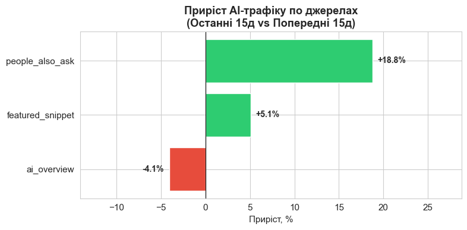

```python
# --- Агрегація сесій по джерелах для кожного періоду ---
def ai_sessions_by_source(df):
    return (
        df[df['source'].isin(AI_SOURCES)]   # залишаємо тільки AI-джерела
        .groupby('source')['sessions']      # групуємо по джерелу
        .sum()                              # сумуємо сесії
    )

# Сесії за попередні та останні 15 днів
src_p1 = ai_sessions_by_source(period1)
src_p2 = ai_sessions_by_source(period2)

# Об’єднуємо в одну таблицю
ai_source_compare = pd.concat([src_p1, src_p2], axis=1).fillna(0)
ai_source_compare.columns = ['p1', 'p2']

# --- Розрахунок приросту ---
ai_source_compare['abs_growth'] = ai_source_compare['p2'] - ai_source_compare['p1']

ai_source_compare['growth_%'] = (
    ai_source_compare['abs_growth'] /
    ai_source_compare['p1'].replace(0, np.nan)  # уникнення ділення на 0
    * 100
).round(1)

# Гарантуємо наявність усіх 3 джерел і правильний порядок
ai_source_compare = ai_source_compare.reindex(AI_SOURCES).fillna(0)

# Сортуємо для зручності відображення
df_src = ai_source_compare['growth_%'].sort_values()

# --- Побудова графіка ---
plt.figure(figsize=(8, 4))

df_src = ai_source_compare['growth_%'].sort_values()

colors = ['#2ecc71' if v >= 0 else '#e74c3c' for v in df_src]

bars = plt.barh(
    df_src.index,
    df_src.values,
    color=colors,
    edgecolor='white'
)

# Лінія 0
plt.axvline(0, color='black', linewidth=0.8)

# --- ДИНАМІЧНІ ВІДСТУПИ ---
max_val = df_src.max()
min_val = df_src.min()

# додаємо запас по краях
plt.xlim(min_val - 10, max_val + 10)
plt.margins(x=0.2)

# --- ПІДПИСИ ---
for bar, val in zip(bars, df_src.values):
    offset = max(abs(max_val), abs(min_val)) * 0.03  # адаптивний відступ

    plt.text(
        val + offset if val >= 0 else val - offset,
        bar.get_y() + bar.get_height() / 2,
        f'{val:+.1f}%',
        va='center',
        ha='left' if val >= 0 else 'right',
        fontsize=10,
        fontweight='bold'
    )

plt.title('Приріст AI-трафіку по джерелах\n(Останні 15д vs Попередні 15д)', fontweight='bold')
plt.xlabel('Приріст, %')

plt.tight_layout()
plt.show()
```

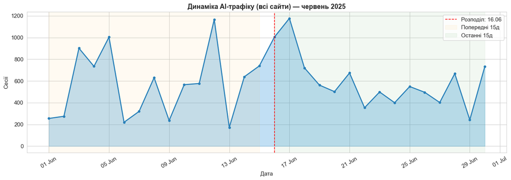

```python
# Динаміка AI-трафіку по днях
ai_daily = (
    traffic[traffic['source'].isin(AI_SOURCES)]
    .groupby('date')['sessions']
    .sum()
    .reset_index()
)

fig, ax = plt.subplots(figsize=(14, 5))
ax.fill_between(ai_daily['date'], ai_daily['sessions'], alpha=0.3, color='#3498db')
ax.plot(ai_daily['date'], ai_daily['sessions'], color='#2980b9', linewidth=2, marker='o', markersize=4)
ax.axvline(period2_start, color='red', linestyle='--', linewidth=1.2,
           label=f'Розподіл: {period2_start.strftime("%d.%m")}')
ax.axvspan(period1_start, period1_end, alpha=0.05, color='orange', label='Попередні 15д')
ax.axvspan(period2_start, max_date, alpha=0.05, color='green', label='Останні 15д')
ax.set_title('Динаміка AI-трафіку (всі сайти) — червень 2025', fontsize=13, fontweight='bold')
ax.set_xlabel('Дата')
ax.set_ylabel('Сесії')
ax.legend()
ax.xaxis.set_major_formatter(plt.matplotlib.dates.DateFormatter('%d %b'))
plt.xticks(rotation=30)
plt.tight_layout()
plt.savefig('visuals/plot_2_ai_daily.png', dpi=150, bbox_inches='tight')
plt.show()
```

## 2. Аналіз продажів

**Правило:** Для сайтів `essayhubpro.net`, `paperwise.co`, `editgenius.net` у регіоні **US** — враховуємо лише нових клієнтів (`is_new_customer = True`).

```python
SPECIAL_SITES = ['essayhubpro.net', 'paperwise.co', 'editgenius.net']

# Маска для рядків, які потрібно виключити:
# сайт входить до SPECIAL_SITES І регіон = US І is_new_customer = False
exclude_mask = (
    orders['site'].isin(SPECIAL_SITES) &
    (orders['region'] == 'US') &
    (orders['is_new_customer'] == False)
)

orders_filtered = orders[~exclude_mask].copy()

print(f'Рядків до фільтрації:  {len(orders)}')
print(f'Рядків після фільтрації: {len(orders_filtered)}')
print(f'Виключено: {exclude_mask.sum()} рядків (повторні клієнти US для 3 сайтів)')
```

```
Рядків до фільтрації:  300
Рядків після фільтрації: 292
Виключено: 8 рядків (повторні клієнти US для 3 сайтів)
```

```python
# --- Продажі по сайтах ---
sales_by_site = (
    orders_filtered
    .groupby('site')
    .agg(
        orders_count=('order_id', 'count'),
        revenue_usd=('amount_usd', 'sum'),
        avg_order_usd=('amount_usd', 'mean'),
        new_customers=('is_new_customer', 'sum')
    )
    .sort_values('revenue_usd', ascending=False)
    .round(2)
)
sales_by_site['new_customer_pct'] = (sales_by_site['new_customers'] / sales_by_site['orders_count'] * 100).round(1)

print('=== Продажі по сайтах ===')
print(sales_by_site.to_string())
```

```
=== Продажі по сайтах ===
                     orders_count  revenue_usd  avg_order_usd  new_customers  new_customer_pct
site
typemaster.org                 40      3472.84          86.82             18              45.0
paperwise.co                   35      2964.16          84.69             19              54.3
leadacademica.co.uk            37      2717.08          73.43             11              29.7
writemaster.co.uk              36      2684.60          74.57              9              25.0
slidecraft.com                 31      2512.43          81.05             11              35.5
progassignments.io             31      2344.34          75.62             14              45.2
editgenius.net                 30      2335.76          77.86             18              60.0
nursingessay.us                26      2178.73          83.80             10              38.5
essayhubpro.net                26      2097.54          80.67             15              57.7
```

```python
# --- Продажі по регіонах ---
sales_by_region = (
    orders_filtered
    .groupby('region')
    .agg(
        orders_count=('order_id', 'count'),
        revenue_usd=('amount_usd', 'sum'),
        avg_order_usd=('amount_usd', 'mean')
    )
    .sort_values('revenue_usd', ascending=False)
    .round(2)
)
print('=== Продажі по регіонах ===')
print(sales_by_region.to_string())
```

```
=== Продажі по регіонах ===
        orders_count  revenue_usd  avg_order_usd
region
AU                66      5664.94          85.83
CA                64      5247.05          81.99
EU                59      4549.48          77.11
US                50      3973.32          79.47
UK                53      3872.69          73.07
```

```python
# --- Продажі по сайту + регіону ---
sales_pivot = (
    orders_filtered
    .groupby(['site', 'region'])['amount_usd']
    .sum()
    .unstack(fill_value=0)
    .round(2)
)
sales_pivot['TOTAL'] = sales_pivot.sum(axis=1)
sales_pivot = sales_pivot.sort_values('TOTAL', ascending=False)
print('=== Дохід ($) по сайту та регіону ===')
print(sales_pivot.to_string())
```

```
=== Дохід ($) по сайту та регіону ===
region                   AU      CA      EU      UK      US    TOTAL
site
typemaster.org       881.05  895.81  503.07  519.54  673.37  3472.84
paperwise.co         774.64  805.33  461.41  492.13  430.65  2964.16
leadacademica.co.uk  647.46  358.41  551.88  560.69  598.64  2717.08
writemaster.co.uk    495.06  599.63  661.22  330.56  598.13  2684.60
slidecraft.com       741.25  289.86  593.35  309.92  578.05  2512.43
progassignments.io   547.67  373.51  343.19  767.24  312.73  2344.34
editgenius.net       548.28  779.87  663.98  197.41  146.22  2335.76
nursingessay.us      600.98  372.79  216.08  519.91  468.97  2178.73
essayhubpro.net      428.55  771.84  555.30  175.29  166.56  2097.54
```

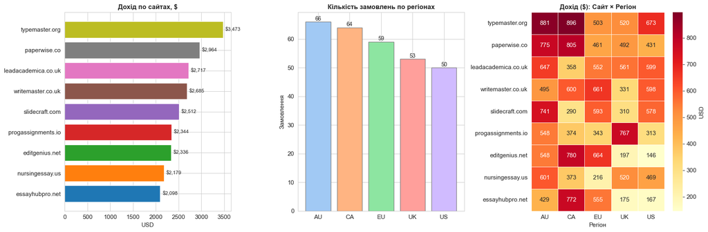

```python
fig, axes = plt.subplots(1, 3, figsize=(18, 6))

# --- Графік 1: Дохід по сайтах ---
site_rev = sales_by_site['revenue_usd'].sort_values()
colors_site = sns.color_palette('tab10', len(site_rev))
bars = axes[0].barh(site_rev.index, site_rev.values, color=colors_site, edgecolor='white')
for bar, val in zip(bars, site_rev.values):
    axes[0].text(val + 50, bar.get_y() + bar.get_height()/2,
                 f'${val:,.0f}', va='center', fontsize=9)
axes[0].set_title('Дохід по сайтах, $', fontsize=12, fontweight='bold')
axes[0].set_xlabel('USD')

# --- Графік 2: Кількість замовлень по регіонах ---
reg_cnt = sales_by_region['orders_count'].sort_values(ascending=False)
axes[1].bar(reg_cnt.index, reg_cnt.values, color=sns.color_palette('pastel', len(reg_cnt)), edgecolor='grey')
axes[1].set_title('Кількість замовлень по регіонах', fontsize=12, fontweight='bold')
axes[1].set_ylabel('Замовлення')
for i, (reg, val) in enumerate(reg_cnt.items()):
    axes[1].text(i, val + 0.5, str(val), ha='center', fontsize=10)

# --- Графік 3: Heatmap дохід сайт x регіон ---
heatmap_data = sales_pivot.drop(columns='TOTAL')
sns.heatmap(heatmap_data, ax=axes[2], annot=True, fmt='.0f', cmap='YlOrRd',
            linewidths=0.5, cbar_kws={'label': 'USD'})
axes[2].set_title('Дохід ($): Сайт × Регіон', fontsize=12, fontweight='bold')
axes[2].set_xlabel('Регіон')
axes[2].set_ylabel('')
axes[2].tick_params(axis='y', rotation=0)

plt.tight_layout()
plt.savefig('visuals/plot_3_sales_overview.png', dpi=150, bbox_inches='tight')
plt.show()
```

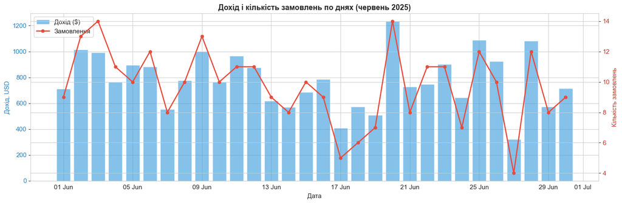

```python
# --- Дохід по днях ---
daily_revenue = (
    orders_filtered
    .groupby('date')['amount_usd']
    .agg(['sum', 'count'])
    .reset_index()
    .rename(columns={'sum': 'revenue', 'count': 'orders'})
)

fig, ax1 = plt.subplots(figsize=(15, 5))

ax1.bar(daily_revenue['date'], daily_revenue['revenue'],
        color='#3498db', alpha=0.6, label='Дохід ($)', width=0.8)
ax1.set_ylabel('Дохід, USD', color='#2980b9')
ax1.tick_params(axis='y', labelcolor='#2980b9')

ax2 = ax1.twinx()
ax2.plot(daily_revenue['date'], daily_revenue['orders'],
         color='#e74c3c', linewidth=2, marker='o', markersize=5, label='Замовлення')
ax2.set_ylabel('Кількість замовлень', color='#c0392b')
ax2.tick_params(axis='y', labelcolor='#c0392b')

lines1, labels1 = ax1.get_legend_handles_labels()
lines2, labels2 = ax2.get_legend_handles_labels()
ax1.legend(lines1 + lines2, labels1 + labels2, loc='upper left')

ax1.set_title('Дохід і кількість замовлень по днях (червень 2025)', fontsize=13, fontweight='bold')
ax1.set_xlabel('Дата')
ax1.xaxis.set_major_formatter(plt.matplotlib.dates.DateFormatter('%d %b'))
plt.xticks(rotation=30)
plt.tight_layout()
plt.savefig('visuals/plot_4_daily_revenue.png', dpi=150, bbox_inches='tight')
plt.show()
```

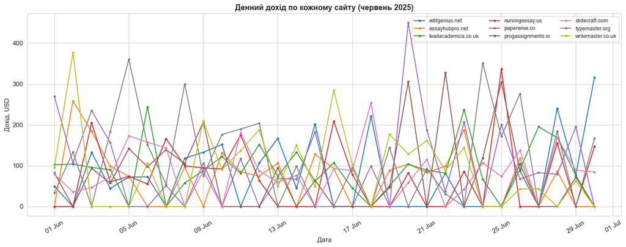

```python
# --- Дохід по днях по кожному сайту ---
daily_by_site = (
    orders_filtered
    .groupby(['date', 'site'])['amount_usd']
    .sum()
    .unstack(fill_value=0)
)

fig, ax = plt.subplots(figsize=(15, 6))
for site in daily_by_site.columns:
    ax.plot(daily_by_site.index, daily_by_site[site], marker='o', markersize=3,
            linewidth=1.5, label=site)

ax.set_title('Денний дохід по кожному сайту (червень 2025)', fontsize=13, fontweight='bold')
ax.set_xlabel('Дата')
ax.set_ylabel('Дохід, USD')
ax.legend(loc='upper right', fontsize=9, ncol=3)
ax.xaxis.set_major_formatter(plt.matplotlib.dates.DateFormatter('%d %b'))
plt.xticks(rotation=30)
plt.tight_layout()
plt.savefig('visuals/plot_5_daily_by_site.png', dpi=150, bbox_inches='tight')
plt.show()
```

## 3. Івенти на сайтах

```python
print('Унікальні типи подій:', events['event'].unique())
print()
print('Кількість подій по типу:')
print(events['event'].value_counts().to_string())
print()
print('Кількість подій по сайту та типу:')
event_pivot = (
    events.groupby(['site', 'event'])
    .size()
    .unstack(fill_value=0)
)
# Впорядкуємо колонки за воронкою
funnel_order = ['cta_click', 'form_submit', 'checkout_initiate', 'conversion']
event_pivot = event_pivot.reindex(columns=[c for c in funnel_order if c in event_pivot.columns])
event_pivot['total_events'] = event_pivot.sum(axis=1)
event_pivot = event_pivot.sort_values('conversion', ascending=False)
print(event_pivot.to_string())
```

```
Унікальні типи подій: <StringArray>
['conversion', 'cta_click', 'checkout_initiate', 'form_submit']
Length: 4, dtype: str

Кількість подій по типу:
event
checkout_initiate    132
cta_click            125
form_submit          125
conversion           118

Кількість подій по сайту та типу:
event                cta_click  form_submit  checkout_initiate  conversion  total_events
site
progassignments.io          15            9                 13          19            56
leadacademica.co.uk         15           18                 10          16            59
writemaster.co.uk           11           11                 16          15            53
slidecraft.com              16           20                 10          14            60
typemaster.org              13           14                 16          14            57
editgenius.net              14           17                 11          13            55
paperwise.co                12           11                 20          11            54
essayhubpro.net             10           11                 19           9            49
nursingessay.us             19           14                 17           7            57
```

```python
# Чи є сайти без жодного conversion?
all_sites = set(events['site'].unique())
sites_with_conversion = set(events[events['event'] == 'conversion']['site'].unique())
sites_without_conversion = all_sites - sites_with_conversion

print(f'Сайти з подіями conversion: {sorted(sites_with_conversion)}')
print()
if sites_without_conversion:
    print(f'Сайти БЕЗ жодного conversion: {sorted(sites_without_conversion)}')
else:
    print('Всі сайти мають хоча б одну подію conversion.')
```

```
Сайти з подіями conversion: ['editgenius.net', 'essayhubpro.net', 'leadacademica.co.uk', 'nursingessay.us', 'paperwise.co', 'progassignments.io', 'slidecraft.com', 'typemaster.org', 'writemaster.co.uk']

Всі сайти мають хоча б одну подію conversion.
```

```python
# Конверсійна воронка по кожному сайту
funnel_cols = [c for c in funnel_order if c in event_pivot.columns]
funnel_data = event_pivot[funnel_cols].copy()

# Конверсія checkout -> conversion та cta -> conversion
funnel_data['cr_cta_to_conv_%'] = (
    funnel_data['conversion'] / funnel_data['cta_click'].replace(0, np.nan) * 100
).round(1)
funnel_data['cr_checkout_to_conv_%'] = (
    funnel_data['conversion'] / funnel_data['checkout_initiate'].replace(0, np.nan) * 100
).round(1)

print('=== Воронка + конверсії по сайтах ===')
print(funnel_data.to_string())
```

```
=== Воронка + конверсії по сайтах ===
event                cta_click  form_submit  checkout_initiate  conversion  cr_cta_to_conv_%  cr_checkout_to_conv_%
site
progassignments.io          15            9                 13          19             126.7                  146.2
leadacademica.co.uk         15           18                 10          16             106.7                  160.0
writemaster.co.uk           11           11                 16          15             136.4                   93.8
slidecraft.com              16           20                 10          14              87.5                  140.0
typemaster.org              13           14                 16          14             107.7                   87.5
editgenius.net              14           17                 11          13              92.9                  118.2
paperwise.co                12           11                 20          11              91.7                   55.0
essayhubpro.net             10           11                 19           9              90.0                   47.4
nursingessay.us             19           14                 17           7              36.8                   41.2
```

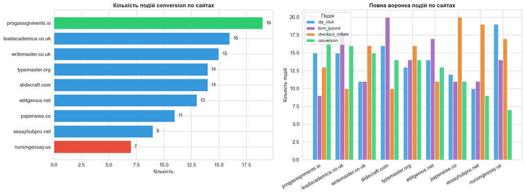

```python
fig, axes = plt.subplots(1, 2, figsize=(16, 6))

# --- Графік 1: Кількість conversion по сайтах ---
conv_data = event_pivot['conversion'].sort_values(ascending=True)
colors_conv = ['#e74c3c' if v == conv_data.min() else '#2ecc71' if v == conv_data.max()
               else '#3498db' for v in conv_data]
bars = axes[0].barh(conv_data.index, conv_data.values, color=colors_conv, edgecolor='white')
for bar, val in zip(bars, conv_data.values):
    axes[0].text(val + 0.3, bar.get_y() + bar.get_height()/2,
                 str(int(val)), va='center', fontsize=10)
axes[0].set_title('Кількість подій conversion по сайтах', fontsize=12, fontweight='bold')
axes[0].set_xlabel('Кількість')

# --- Графік 2: Стовпчаста повна воронка ---
funnel_plot = event_pivot[funnel_cols].sort_values('conversion', ascending=False)
x = np.arange(len(funnel_plot))
width = 0.2
colors_funnel = ['#3498db', '#9b59b6', '#e67e22', '#2ecc71']
for i, (col, color) in enumerate(zip(funnel_cols, colors_funnel)):
    axes[1].bar(x + i * width, funnel_plot[col], width=width,
                label=col, color=color, alpha=0.85, edgecolor='white')
axes[1].set_xticks(x + width * 1.5)
axes[1].set_xticklabels(funnel_plot.index, rotation=30, ha='right')
axes[1].set_title('Повна воронка подій по сайтах', fontsize=12, fontweight='bold')
axes[1].set_ylabel('Кількість подій')
axes[1].legend(title='Подія', fontsize=9)

plt.tight_layout()
plt.savefig('visuals/plot_6_events_funnel.png', dpi=150, bbox_inches='tight')
plt.show()
```

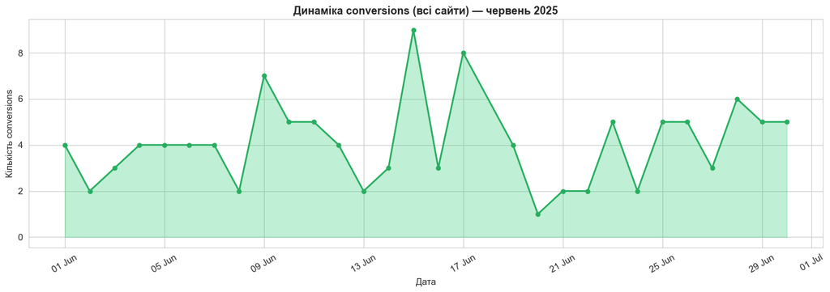

```python
# Динаміка conversions по днях
conv_daily = (
    events[events['event'] == 'conversion']
    .groupby(['timestamp', 'site'])
    .size()
    .reset_index(name='count')
)
conv_daily_total = conv_daily.groupby('timestamp')['count'].sum().reset_index()

fig, ax = plt.subplots(figsize=(14, 5))
ax.fill_between(conv_daily_total['timestamp'], conv_daily_total['count'], alpha=0.3, color='#2ecc71')
ax.plot(conv_daily_total['timestamp'], conv_daily_total['count'],
        color='#27ae60', linewidth=2, marker='o', markersize=5)
ax.set_title('Динаміка conversions (всі сайти) — червень 2025', fontsize=13, fontweight='bold')
ax.set_xlabel('Дата')
ax.set_ylabel('Кількість conversions')
ax.xaxis.set_major_formatter(plt.matplotlib.dates.DateFormatter('%d %b'))
plt.xticks(rotation=30)
plt.tight_layout()
plt.savefig('visuals/plot_7_conversions_daily.png', dpi=150, bbox_inches='tight')
plt.show()
```

## Критично важливі події для розуміння поведінки користувачів

| Крок | Подія | Значення |
| --- | --- | --- |
| 1 | **session_start / page_view** | Перший контакт з сайтом (у даних відсутня, але необхідна) |
| 2 | **cta_click** | Інтерес до пропозиції — клік на кнопку дії |
| 3 | **form_submit** | Готовність до оформлення — заповнення форми |
| 4 | **checkout_initiate** | Намір купити — перехід до оплати |
| 5 | **conversion** | Успішна покупка |

**Відсутні в даних, але критично важливі:**

- `page_view` / `session_start` — без цього неможливо порахувати реальний CR від сесії до дії
- `checkout_abandon` — залишення кошика, ключова точка втрат
- `form_error` — помилки форм, що блокують конверсію
- `return_visit` — повторні відвідування до конверсії

## 4. Бізнес-гіпотези та рекомендації

```python
# === Підготовка даних для гіпотез ===

# 1. AI-трафік vs кількість замовлень по сайту
ai_total_by_site = (
    traffic[traffic['source'].isin(AI_SOURCES)]
    .groupby('site')['sessions']
    .sum()
    .rename('ai_sessions')
    .to_frame()  # Series -> DataFrame для join
)
orders_by_site = orders_filtered.groupby('site').agg(
    total_orders=('order_id', 'count'),
    total_revenue=('amount_usd', 'sum')
)
hypothesis_df = ai_total_by_site.join(orders_by_site, how='outer').fillna(0)
hypothesis_df['ai_to_order_ratio'] = (
    hypothesis_df['total_orders'] / hypothesis_df['ai_sessions'].replace(0, np.nan)
).round(4)

print('=== AI-трафік vs Замовлення по сайтах ===')
print(hypothesis_df.sort_values('ai_to_order_ratio', ascending=False).to_string())
```

```
=== AI-трафік vs Замовлення по сайтах ===
                     ai_sessions  total_orders  total_revenue  ai_to_order_ratio
site
editgenius.net              1048            30        2335.76             0.0286
writemaster.co.uk           1278            36        2684.60             0.0282
typemaster.org              1611            40        3472.84             0.0248
progassignments.io          1721            31        2344.34             0.0180
paperwise.co                2131            35        2964.16             0.0164
leadacademica.co.uk         2682            37        2717.08             0.0138
slidecraft.com              2368            31        2512.43             0.0131
nursingessay.us             2241            26        2178.73             0.0116
essayhubpro.net             2342            26        2097.54             0.0111
```

```python
# 2. CR воронки: checkout_initiate -> conversion
checkout_cnt = events[events['event'] == 'checkout_initiate'].groupby('site').size().rename('checkout')
conv_cnt = events[events['event'] == 'conversion'].groupby('site').size().rename('conversion')
funnel_cr = pd.concat([checkout_cnt, conv_cnt], axis=1).fillna(0)
funnel_cr['checkout_to_conv_cr'] = (funnel_cr['conversion'] / funnel_cr['checkout'].replace(0, np.nan) * 100).round(1)
funnel_cr = funnel_cr.sort_values('checkout_to_conv_cr', ascending=False)

print('=== CR: checkout -> conversion по сайтах ===')
print(funnel_cr.to_string())
```

```
=== CR: checkout -> conversion по сайтах ===
                     checkout  conversion  checkout_to_conv_cr
site
leadacademica.co.uk        10          16                160.0
progassignments.io         13          19                146.2
slidecraft.com             10          14                140.0
editgenius.net             11          13                118.2
writemaster.co.uk          16          15                 93.8
typemaster.org             16          14                 87.5
paperwise.co               20          11                 55.0
essayhubpro.net            19           9                 47.4
nursingessay.us            17           7                 41.2
```

```python
# 3. Частка нових клієнтів та середній чек
new_vs_old = orders.groupby('site').agg(
    new_customers=('is_new_customer', 'sum'),
    total=('order_id', 'count'),
    avg_new_usd=('amount_usd', lambda x: x[orders.loc[x.index, 'is_new_customer']].mean()),
    avg_ret_usd=('amount_usd', lambda x: x[~orders.loc[x.index, 'is_new_customer']].mean())
).round(2)
new_vs_old['new_pct'] = (new_vs_old['new_customers'] / new_vs_old['total'] * 100).round(1)
print('=== Нові vs Повторні клієнти по сайтах ===')
print(new_vs_old.sort_values('new_pct', ascending=False).to_string())
```

```
=== Нові vs Повторні клієнти по сайтах ===
                     new_customers  total  avg_new_usd  avg_ret_usd  new_pct
site
editgenius.net                  18     33        76.29        80.89     54.5
essayhubpro.net                 15     28        77.23        83.86     53.6
paperwise.co                    19     38        84.51        85.18     50.0
progassignments.io              14     31        77.69        73.92     45.2
typemaster.org                  18     40        86.22        87.31     45.0
nursingessay.us                 10     26        88.83        80.65     38.5
slidecraft.com                  11     31        74.25        84.78     35.5
leadacademica.co.uk             11     37        71.36        74.31     29.7
writemaster.co.uk                9     36        83.45        71.61     25.0
```

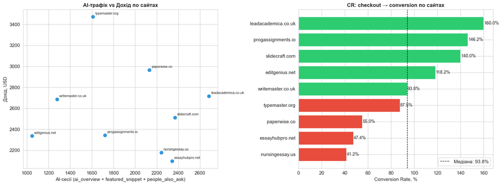

```python
fig, axes = plt.subplots(1, 2, figsize=(16, 6))

# --- Scatter: AI сесії vs Дохід ---
scatter_df = hypothesis_df.copy()
axes[0].scatter(scatter_df['ai_sessions'], scatter_df['total_revenue'],
                s=100, color='#3498db', edgecolors='white', linewidth=1.5, zorder=3)
for site, row in scatter_df.iterrows():
    axes[0].annotate(site, (row['ai_sessions'], row['total_revenue']),
                     textcoords='offset points', xytext=(5, 5), fontsize=8)
axes[0].set_title('AI-трафік vs Дохід по сайтах', fontsize=12, fontweight='bold')
axes[0].set_xlabel('AI-сесії (ai_overview + featured_snippet + people_also_ask)')
axes[0].set_ylabel('Дохід, USD')

# --- CR воронки по сайтах ---
cr_sorted = funnel_cr['checkout_to_conv_cr'].sort_values(ascending=True)
colors_cr = ['#e74c3c' if v < cr_sorted.median() else '#2ecc71' for v in cr_sorted]
bars = axes[1].barh(cr_sorted.index, cr_sorted.values, color=colors_cr, edgecolor='white')
axes[1].axvline(cr_sorted.median(), color='black', linestyle='--', linewidth=1, label=f'Медіана: {cr_sorted.median():.1f}%')
for bar, val in zip(bars, cr_sorted.values):
    axes[1].text(val + 0.3, bar.get_y() + bar.get_height()/2,
                 f'{val:.1f}%', va='center', fontsize=10)
axes[1].set_title('CR: checkout → conversion по сайтах', fontsize=12, fontweight='bold')
axes[1].set_xlabel('Conversion Rate, %')
axes[1].legend()

plt.tight_layout()
plt.savefig('visuals/plot_8_hypotheses.png', dpi=150, bbox_inches='tight')
plt.show()
```

## Бізнес-гіпотези та рекомендації

### Гіпотеза 1: AI-трафік недостатньо монетизується на сайтах з низьким CR

**Спостереження:** Частина сайтів отримує значний обсяг AI-трафіку (ai_overview, featured_snippet, people_also_ask), але конверсія в замовлення залишається низькою. Це може свідчити про невідповідність між інформаційним наміром AI-запитів та комерційною пропозицією сторінки приземлення.

**Рекомендація:** Для сайтів, де `ai_to_order_ratio` нижчий за середнє — провести A/B тест landing page з чіткішим CTA та соціальними доказами. Окремо проаналізувати, які ключові слова тригерять AI Overview — вони можуть бути занадто загальними.

### Гіпотеза 2: Висока частка abandoned checkout — головна точка втрат у воронці

**Спостереження:** Порівнюючи `checkout_initiate` та `conversion`, бачимо, що CR на останньому кроці воронки суттєво відрізняється між сайтами. Сайти з низьким CR (< медіани) вочевидь мають проблеми на сторінці оплати або фінального оформлення.

**Рекомендація:** Впровадити email/push-ремаркетинг для користувачів, що залишили checkout. За даними e-commerce, відновлення 10–15% abandoned checkouts дає суттєвий приріст доходу. Також — спростити форму оплати та додати додаткові методи оплати.

### Гіпотеза 3: Нові клієнти в US-регіоні мають вищий потенціал для retention-кампаній

**Спостереження:** Для трьох сайтів (essayhubpro.net, paperwise.co, editgenius.net) у регіоні US помітна значна частка нових клієнтів. Якщо середній чек нових клієнтів співставний із повторними — це сигнал, що ці сайти добре залучають, але потенційно не утримують аудиторію.

**Рекомендація:** Запустити retention-кампанії (email-серія після першого замовлення, програма лояльності, персоналізовані пропозиції). Збільшення LTV навіть на 20% від існуючої бази дасть більший ROI, ніж додаткові витрати на залучення нових клієнтів.

```python
# === Фінальний Summary ===
print('=' * 60)
print('ФІНАЛЬНИЙ ЗВІТ — ЧЕРВЕНЬ 2025')
print('=' * 60)

total_ai = traffic[traffic['source'].isin(AI_SOURCES)]['sessions'].sum()
total_sessions = traffic['sessions'].sum()
print(f"\nТРАФІК:")
print(f"  Загальні сесії:          {total_sessions:,}")
print(f"  AI-сесії:                {total_ai:,}  ({total_ai/total_sessions*100:.1f}%)")
print(f"  Топ-сайт за AI-ростом:   {ai_compare['Відн. приріст, %'].idxmax()} ({ai_compare['Відн. приріст, %'].max():+.1f}%)")

print(f"\nПРОДАЖІ (після фільтрації):")
print(f"  Загальна кількість замовлень: {len(orders_filtered)}")
print(f"  Загальний дохід:              ${orders_filtered['amount_usd'].sum():,.2f}")
print(f"  Середній чек:                 ${orders_filtered['amount_usd'].mean():.2f}")
print(f"  Топ-сайт за доходом:          {sales_by_site['revenue_usd'].idxmax()} (${sales_by_site['revenue_usd'].max():,.2f})")
print(f"  Топ-регіон:                   {sales_by_region['revenue_usd'].idxmax()} (${sales_by_region['revenue_usd'].max():,.2f})")

print(f"\nІВЕНТИ:")
print(f"  Загальна кількість подій:     {len(events)}")
print(f"  Всього conversions:           {events[events['event']=='conversion'].shape[0]}")
top_conv_site = event_pivot['conversion'].idxmax()
print(f"  Топ-сайт за conversions:      {top_conv_site} ({int(event_pivot.loc[top_conv_site, 'conversion'])})")
print(f"  Сайти без conversion:         {'Немає' if not sites_without_conversion else sites_without_conversion}")
print(f"  Медіанний CR checkout->conv:  {funnel_cr['checkout_to_conv_cr'].median():.1f}%")
print('=' * 60)
```

```
============================================================
ФІНАЛЬНИЙ ЗВІТ — ЧЕРВЕНЬ 2025
============================================================

ТРАФІК:
  Загальні сесії:          39,664
  AI-сесії:                17,422  (43.9%)
  Топ-сайт за AI-ростом:   leadacademica.co.uk (+174.6%)

ПРОДАЖІ (після фільтрації):
  Загальна кількість замовлень: 292
  Загальний дохід:              $23,307.48
  Середній чек:                 $79.82
  Топ-сайт за доходом:          typemaster.org ($3,472.84)
  Топ-регіон:                   AU ($5,664.94)

ІВЕНТИ:
  Загальна кількість подій:     500
  Всього conversions:           118
  Топ-сайт за conversions:      progassignments.io (19)
  Сайти без conversion:         Немає
  Медіанний CR checkout->conv:  93.8%
============================================================
```